# Assignment 2

## Andrew Singh

### 11/20/2024

#### Q1

#### Read in worldbank_gapminder.csv Download worldbank_gapminder.csv using pandas

```python
import pandas as pd
import numpy as np
import seaborn as sns
%pip install altair
import altair as alt
```

```python
WorldBank = pd.read_csv("worldbank_gapminder.csv")
```

#### Q2

#### Check the data types of the DataFrame.

```python
WorldBank.dtypes
```

```
Unnamed: 0      int64
country        object
continent      object
year            int64
lifeExp       float64
pop             int64
gdpPercap     float64
dtype: object
```

#### Q3

#### What is the data type of the lifeExp columns? What is the data type of continent column?

```python
print(type(WorldBank["lifeExp"]))
print(type(WorldBank["continent"]))
```

```
<class 'pandas.core.series.Series'>
<class 'pandas.core.series.Series'>
```

#### Q4

#### Convert the columns with data type "object" to "category" using bracket notation.

#### Convert the columns with data type "object" to "category" using dot notation.

```python
## Convert using bracket notation

WorldBank["country"] = WorldBank["country"].astype("category")
WorldBank["continent"] = WorldBank["continent"].astype("category")

## Convert using dot notation

WorldBank.country = WorldBank.country.astype("category")
WorldBank.continent = WorldBank.continent.astype("category")
```

```python
## Check for the recoded variables
WorldBank.dtypes
```

```
Unnamed: 0       int64
country       category
continent     category
year             int64
lifeExp        float64
pop              int64
gdpPercap      float64
dtype: object
```

#### Q5

#### Write code to check the total number of missing values in each column.

```python
WorldBank.isnull().sum()
```

```
Unnamed: 0    0
country       0
continent     0
year          0
lifeExp       0
pop           0
gdpPercap     0
dtype: int64
```

#### Q6

#### How many rows and columns does the dataset contain? How would you find this information?

```python
print(WorldBank.shape)
```

```
(1704, 7)
```

The total count of rows for the World Bank dataset is 1,704 rows, while the total number of columns is 7. We would find out the dimensions of the dataset by using the shape command in Python.

#### Q7

#### What is the lifeExp value in the third row of the dataset?

```python
print(WorldBank.head())
```

```
   Unnamed: 0      country continent  year  lifeExp       pop   gdpPercap
0           1  Afghanistan      Asia  1952   28.801   8425333  779.445314
1           2  Afghanistan      Asia  1957   30.332   9240934  820.853030
2           3  Afghanistan      Asia  1962   31.997  10267083  853.100710
3           4  Afghanistan      Asia  1967   34.020  11537966  836.197138
4           5  Afghanistan      Asia  1972   36.088  13079460  739.981106
```

The lifeExp value in the third row of the dataset is 31.997.

#### Q8

#### What is the max gdpPercap in the dataset?

```python
print(WorldBank.describe())
```

```
        Unnamed: 0        year      lifeExp           pop      gdpPercap
count  1704.000000  1704.00000  1704.000000  1.704000e+03    1704.000000
mean    852.500000  1979.50000    59.474439  2.960121e+07    7215.327081
std     492.046746    17.26533    12.917107  1.061579e+08    9857.454543
min       1.000000  1952.00000    23.599000  6.001100e+04     241.165876
25%     426.750000  1965.75000    48.198000  2.793664e+06    1202.060309
50%     852.500000  1979.50000    60.712500  7.023596e+06    3531.846988
75%    1278.250000  1993.25000    70.845500  1.958522e+07    9325.462346
max    1704.000000  2007.00000    82.603000  1.318683e+09  113523.132900
```

The max gdpPercap in the dataset is $113523.132900.

#### Q9

#### What is the mean and SD of lifeExp in the dataset?

Based on the descriptive statistics table above, for the variable lifeExp in the dataset the mean is 59.474439 years old, while the standard deviation is 12.917107 years old.

#### Q10

#### Create a smaller dataset called europe_df with only rows from Europe.

```python
print(WorldBank)
```

```
      Unnamed: 0      country continent  year  lifeExp       pop   gdpPercap
0              1  Afghanistan      Asia  1952   28.801   8425333  779.445314
1              2  Afghanistan      Asia  1957   30.332   9240934  820.853030
2              3  Afghanistan      Asia  1962   31.997  10267083  853.100710
3              4  Afghanistan      Asia  1967   34.020  11537966  836.197138
4              5  Afghanistan      Asia  1972   36.088  13079460  739.981106
...          ...          ...       ...   ...      ...       ...         ...
1699        1700     Zimbabwe    Africa  1987   62.351   9216418  706.157306
1700        1701     Zimbabwe    Africa  1992   60.377  10704340  693.420786
1701        1702     Zimbabwe    Africa  1997   46.809  11404948  792.449960
1702        1703     Zimbabwe    Africa  2002   39.989  11926563  672.038623
1703        1704     Zimbabwe    Africa  2007   43.487  12311143  469.709298

[1704 rows x 7 columns]
```

```python
europe_df = WorldBank[WorldBank["continent"] == "Europe"]
```

```python
print(europe_df)
```

```
      Unnamed: 0         country continent  year  lifeExp       pop  \
12            13         Albania    Europe  1952   55.230   1282697
13            14         Albania    Europe  1957   59.280   1476505
14            15         Albania    Europe  1962   64.820   1728137
15            16         Albania    Europe  1967   66.220   1984060
16            17         Albania    Europe  1972   67.690   2263554
...          ...             ...       ...   ...      ...       ...
1603        1604  United Kingdom    Europe  1987   75.007  56981620
1604        1605  United Kingdom    Europe  1992   76.420  57866349
1605        1606  United Kingdom    Europe  1997   77.218  58808266
1606        1607  United Kingdom    Europe  2002   78.471  59912431
1607        1608  United Kingdom    Europe  2007   79.425  60776238

         gdpPercap
12     1601.056136
13     1942.284244
14     2312.888958
15     2760.196931
16     3313.422188
...            ...
1603  21664.787670
1604  22705.092540
1605  26074.531360
1606  29478.999190
1607  33203.261280

[360 rows x 7 columns]
```

#### Q11

#### How many rows and columns does europe_df contain?

```python
europe_df.shape
```

```
(360, 7)
```

The DataFrame europe_df contains 360 rows and 7 columns.

#### Q12

#### Create an even smaller dataset--called small_europe--from europe_df with only rows in 2002 and from Germany and Austria and France.

```python
small_europe = europe_df[
    (europe_df["year"] == 2002) &
    ((europe_df["country"] == "Germany") |
     (europe_df["country"] == "Austria") |
     (europe_df["country"] == "France"))].head(5)
```

```python
small_europe
```

|  | Unnamed: 0 | country | continent | year | lifeExp | pop | gdpPercap |
| --- | --- | --- | --- | --- | --- | --- | --- |
| 82 | 83 | Austria | Europe | 2002 | 78.98 | 8148312 | 32417.60769 |
| 538 | 539 | France | Europe | 2002 | 79.59 | 59925035 | 28926.03234 |
| 574 | 575 | Germany | Europe | 2002 | 78.67 | 82350671 | 30035.80198 |

#### Q13

#### Which country in small_europe has the highest life expectancy?

The country in small_europe that has the highest life expectancy is France with the highest life expectancy being 79.59 years old.

#### Q14

#### What is the mean and SD life expectancy in Africa excluding Zambia and Tunisia?

```python
africa = WorldBank[(WorldBank["continent"] == "Africa") &
            (WorldBank["country"] != "Zambia") &
            (WorldBank["country"] != "Tunisia")]
```

```python
africa
```

|  | Unnamed: 0 | country | continent | year | lifeExp | pop | gdpPercap |
| --- | --- | --- | --- | --- | --- | --- | --- |
| 24 | 25 | Algeria | Africa | 1952 | 43.077 | 9279525 | 2449.008185 |
| 25 | 26 | Algeria | Africa | 1957 | 45.685 | 10270856 | 3013.976023 |
| 26 | 27 | Algeria | Africa | 1962 | 48.303 | 11000948 | 2550.816880 |
| 27 | 28 | Algeria | Africa | 1967 | 51.407 | 12760499 | 3246.991771 |
| 28 | 29 | Algeria | Africa | 1972 | 54.518 | 14760787 | 4182.663766 |
| ... | ... | ... | ... | ... | ... | ... | ... |
| 1699 | 1700 | Zimbabwe | Africa | 1987 | 62.351 | 9216418 | 706.157306 |
| 1700 | 1701 | Zimbabwe | Africa | 1992 | 60.377 | 10704340 | 693.420786 |
| 1701 | 1702 | Zimbabwe | Africa | 1997 | 46.809 | 11404948 | 792.449960 |
| 1702 | 1703 | Zimbabwe | Africa | 2002 | 39.989 | 11926563 | 672.038623 |
| 1703 | 1704 | Zimbabwe | Africa | 2007 | 43.487 | 12311143 | 469.709298 |

600 rows × 7 columns

```python
africa.describe()
```

|  | Unnamed: 0 | year | lifeExp | pop | gdpPercap |
| --- | --- | --- | --- | --- | --- |
| count | 600.000000 | 600.000000 | 600.000000 | 6.000000e+02 | 600.000000 |
| mean | 809.060000 | 1979.500000 | 48.685597 | 1.005183e+07 | 2184.796566 |
| std | 472.430044 | 17.274664 | 9.033313 | 1.577411e+07 | 2865.297309 |
| min | 25.000000 | 1952.000000 | 23.599000 | 6.001100e+04 | 241.165876 |
| 25% | 366.750000 | 1965.750000 | 42.213000 | 1.279100e+06 | 744.873915 |
| 50% | 888.500000 | 1979.500000 | 47.684500 | 4.442422e+06 | 1172.635351 |
| 75% | 1266.250000 | 1993.250000 | 54.337000 | 1.113106e+07 | 2368.642456 |
| max | 1704.000000 | 2007.000000 | 76.442000 | 1.350312e+08 | 21951.211760 |

The mean life expectancy in Africa excluding Zambia and Tunisia is 48.685597 years old, while the standard deviation for life expentancy is 9.033313 years old.

#### Q15

#### Each column in a DataFrame is a data structure called a…?

Each column in a DataFrame is a data structure called a series.

#### Q16

#### Create a new column called high_exp that is 1 if lifeExp is greater than 75 and 0 otherwise.

```python
WorldBank['high_exp'] = np.where(WorldBank["lifeExp"] > 75,
                                    1,
                                    0)
```

```python
print(WorldBank.head())
```

```
   Unnamed: 0      country continent  year  lifeExp       pop   gdpPercap  \
0           1  Afghanistan      Asia  1952   28.801   8425333  779.445314
1           2  Afghanistan      Asia  1957   30.332   9240934  820.853030
2           3  Afghanistan      Asia  1962   31.997  10267083  853.100710
3           4  Afghanistan      Asia  1967   34.020  11537966  836.197138
4           5  Afghanistan      Asia  1972   36.088  13079460  739.981106

   high_exp
0         0
1         0
2         0
3         0
4         0
```

#### Q17

#### Subset the data to create a small dataset with only countries with high life expectancy rows called high_df.

```python
high_df = WorldBank[WorldBank["high_exp"] == 1]
```

```python
print(high_df.head())
```

```
    Unnamed: 0    country continent  year  lifeExp       pop     gdpPercap  \
22          23    Albania    Europe  2002   75.651   3508512   4604.211737
23          24    Albania    Europe  2007   76.423   3600523   5937.029526
59          60  Argentina  Americas  2007   75.320  40301927  12779.379640
67          68  Australia   Oceania  1987   76.320  16257249  21888.889030
68          69  Australia   Oceania  1992   77.560  17481977  23424.766830

    high_exp
22         1
23         1
59         1
67         1
68         1
```

#### Q18

#### Subset the data to create a small dataset with only countries with low life expectancy (75 or less) called low_df.

```python
low_df = WorldBank[WorldBank["high_exp"] == 0]
```

```python
print(low_df.head())
```

```
   Unnamed: 0      country continent  year  lifeExp       pop   gdpPercap  \
0           1  Afghanistan      Asia  1952   28.801   8425333  779.445314
1           2  Afghanistan      Asia  1957   30.332   9240934  820.853030
2           3  Afghanistan      Asia  1962   31.997  10267083  853.100710
3           4  Afghanistan      Asia  1967   34.020  11537966  836.197138
4           5  Afghanistan      Asia  1972   36.088  13079460  739.981106

   high_exp
0         0
1         0
2         0
3         0
4         0
```

#### Q19

#### What is the mean gdpPercap of in the high_df and mean gdpPercap in low_df.

```python
high_df['gdpPercap'].mean()
```

```
24704.287164069363
```

```python
high_df.describe()
```

|  | Unnamed: 0 | year | lifeExp | pop | gdpPercap | high_exp |
| --- | --- | --- | --- | --- | --- | --- |
| count | 173.000000 | 173.000000 | 173.000000 | 1.730000e+02 | 173.000000 | 173.0 |
| mean | 859.421965 | 1997.289017 | 77.681434 | 2.901734e+07 | 24704.287164 | 1.0 |
| std | 478.888783 | 8.468666 | 1.802373 | 5.141318e+07 | 9101.683925 | 0.0 |
| min | 23.000000 | 1977.000000 | 75.007000 | 2.218230e+05 | 4604.211737 | 1.0 |
| 25% | 527.000000 | 1992.000000 | 76.151000 | 4.186147e+06 | 19328.709010 | 1.0 |
| 50% | 780.000000 | 1997.000000 | 77.420000 | 8.954175e+06 | 25144.392010 | 1.0 |
| 75% | 1271.000000 | 2007.000000 | 78.820000 | 3.190227e+07 | 30281.704590 | 1.0 |
| max | 1632.000000 | 2007.000000 | 82.603000 | 3.011399e+08 | 49357.190170 | 1.0 |

The mean gdpPercapita in high_df is $24,704.28.

```python
low_df['gdpPercap'].mean()
```

```
5239.108861529393
```

```python
low_df.describe()
```

|  | Unnamed: 0 | year | lifeExp | pop | gdpPercap | high_exp |
| --- | --- | --- | --- | --- | --- | --- |
| count | 1531.000000 | 1531.000000 | 1531.000000 | 1.531000e+03 | 1531.000000 | 1531.0 |
| mean | 851.717831 | 1977.489876 | 57.417085 | 2.966719e+07 | 5239.108862 | 0.0 |
| std | 493.658197 | 16.849635 | 11.984761 | 1.106642e+08 | 7768.600400 | 0.0 |
| min | 1.000000 | 1952.000000 | 23.599000 | 6.001100e+04 | 241.165876 | 0.0 |
| 25% | 424.500000 | 1962.000000 | 47.003000 | 2.646863e+06 | 1073.509281 | 0.0 |
| 50% | 866.000000 | 1977.000000 | 58.161000 | 6.893451e+06 | 2860.169750 | 0.0 |
| 75% | 1279.500000 | 1992.000000 | 69.151000 | 1.859106e+07 | 7019.705463 | 0.0 |
| max | 1704.000000 | 2007.000000 | 74.994000 | 1.318683e+09 | 113523.132900 | 0.0 |

The mean gdpPercapita in low_df is $5,239.10.

#### Q20

#### In one line of code, using the full dataset, calculate the mean gdpPercap for countries with lifeExp greater than 75 and for countries with lifeExp less than or equal to 75.

```python
WorldBank.groupby(WorldBank['high_exp'])['gdpPercap'].mean()
```

```
high_exp
0     5239.108862
1    24704.287164
Name: gdpPercap, dtype: float64
```

#### Q21

#### Use normalized crosstabs to display, within each continent, the percentage of rows that are considered high life expectancy (high_exp == 1).

```python
Q21 = pd.crosstab(WorldBank['continent'],
               WorldBank['high_exp'],
               normalize = 'index')
```

```python
print(Q21)
```

```
high_exp          0         1
continent
Africa     0.996795  0.003205
Americas   0.906667  0.093333
Asia       0.916667  0.083333
Europe     0.719444  0.280556
Oceania    0.625000  0.375000
```

#### Q22

#### What percentage of data from the Americas have high life expectancy?

The percentage of data from the Americas having a high life expectancy is 9.33%.

#### Q23

#### Create a new column that is the log of the gdpPercap column and create a scatter plot (with matplotlib, seaborn, or altair) with log of gdp on the x-axis and life expectancy on the y-axis. Drawing on this plot and the result from #25, write a paragraph explaining your results and some potential explanations for the relationship or lack thereof.

```python
WorldBank['log_gdpPercap'] = np.log(WorldBank['gdpPercap'])
```

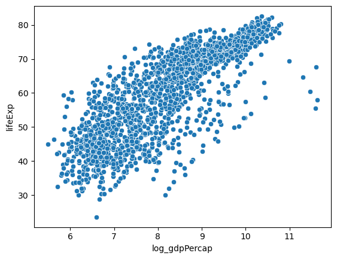

```python
# plot log of gdpPercap on the x-axis and life expectancy on the y-axis.
sns.scatterplot(WorldBank,
                x = "log_gdpPercap",
                y = "lifeExp");
```

#### Drawing on this plot and the result from #25, write a paragraph explaining your results and some potential explanations for the relationship or lack thereof.

From the scatterplot from Q23, there is a relationship between the log of gdpPercap and lifeExp, as we can see the relationship between both quantitative variables is a positive relationship that is increasing as log of gdpPercap increases, lifeExp increases in comparision. The relationship between each of the continents is not made as apparent due to the fact that we do not colorcode the scatterplot by the column 'continent'. We see that for the scatterplot created in Q25, the slopes are still positive but each slope for specific countries are more steeper than others. For example, in the scatterplot of Q25, from pure observation the slope of Europe is steeper than the slope of Asia. In Q25, the relationship between log gdpPercap and lifeExp is made clearer for each specific continent than Q23.

#### Q24

#### Create another scatterplot (with matplotlib, seaborn, or altair) with log of gdp and life expectancy and color the points by continent.

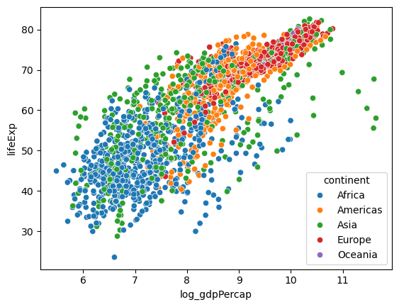

```python
# plot log of gdpPercap on the x-axis and life expectancy on the y-axis.
sns.scatterplot(WorldBank,
                x = "log_gdpPercap",
                y = "lifeExp",
                hue = "continent");
```

##### Q25

#### Create a scatterplot with altair with log of gdp and life expectancy, color the points by continent, add tooltip functionality so that hovering over the data points will show the continent, country, and year of that data point, and add a title.

```python
# Plot log of gdpPercap and life expectancy

alt.Chart(WorldBank).mark_circle().encode(
    x = "log_gdpPercap",
    y = "lifeExp")
```

[interactive chart not shown]

```python
# Add color by continent and title
alt.Chart(WorldBank).mark_circle().encode(
    x = "log_gdpPercap",
    y = "lifeExp",
    color = "continent"). \
    properties(title = "Log GDP Per Capita vs Life Expectancy").interactive()
```

[interactive chart not shown]

```python
# Add color by continent, title, and tooltip
alt.Chart(WorldBank).mark_circle().encode(
    x = "log_gdpPercap",
    y = "lifeExp",
    color = "continent",
    tooltip = ["continent","country","year"]). \
    properties(title = "Log GDP Per Capita vs Life Expectancy").interactive()
```

[interactive chart not shown]